# Calculus

## What is a function?

### Formal definition

In school we are leraning that a function is a rule that assigns to each element of a set $X$ exactly one element of a set $Y$. This is a part of the definition of a function. Having a receipt for a cake is not a cake. Similarly, having a rule for a function is not a function yet.

**Set-theory definition of a function** states that a function $f$ is a special case of a two argument relation. A two argument relation is simply any set of ordered pairs of elements from two sets $X$ and $Y$. A function, on the other hand, is a relation $f \subseteq X \times Y$ that satisfies an additional condition: for each element $x \in X$, there is **exactly one** element $y \in Y$ assigned to it.

Formally, a function $f$ is a relation that satisfies the following condition:

$$\forall x_1, x_2 \in X, \, \forall y_1, y_2 \in Y \, \left( (x_1, y_1) \in f \land (x_2, y_2) \in f : (x_1 = x_2) \Rightarrow (y_1 = y_2) \right)$$

This means that if for the same $x_1$ we have two pairs $(x_1, y_1)$ and $(x_1, y_2)$, then $y_1$ must be equal to $y_2$. In other words, no element from $X$ can be “associated” with more than one element from $Y$.

##### Important Points

1. **Relation** in set theory is simply a set of ordered pairs $(x, y)$, where $x$ comes from set $X$ and $y$ comes from set $Y$.
2. **Function** is a relation that additionally satisfies the condition that for every $x$ there is exactly one pair $(x, y)$ in this relation.

Thus, a function $f \subseteq X \times Y$ is a relation that satisfies the additional condition that for each $x \in X$ there is exactly one $y \in Y$ such that $(x, y) \in f$.

#### Examples

**Example 1**

$$f=\{(\text{dog}, \text{pies}), (\text{cat}, \text{kot}), (\text{horse}, \text{koń})\}$$

**Example 2**

$$f=\{(1,2), (2,3), (3,4)\}$$

This means that $f(1)=2$, $f(2)=3$, and $f(3)=4$.

**Example 3**

$$f=\{(1,1),(2,1/2),(3,1/3),...\}=\{(n,1/n): n \in \mathbb{N}\}$$

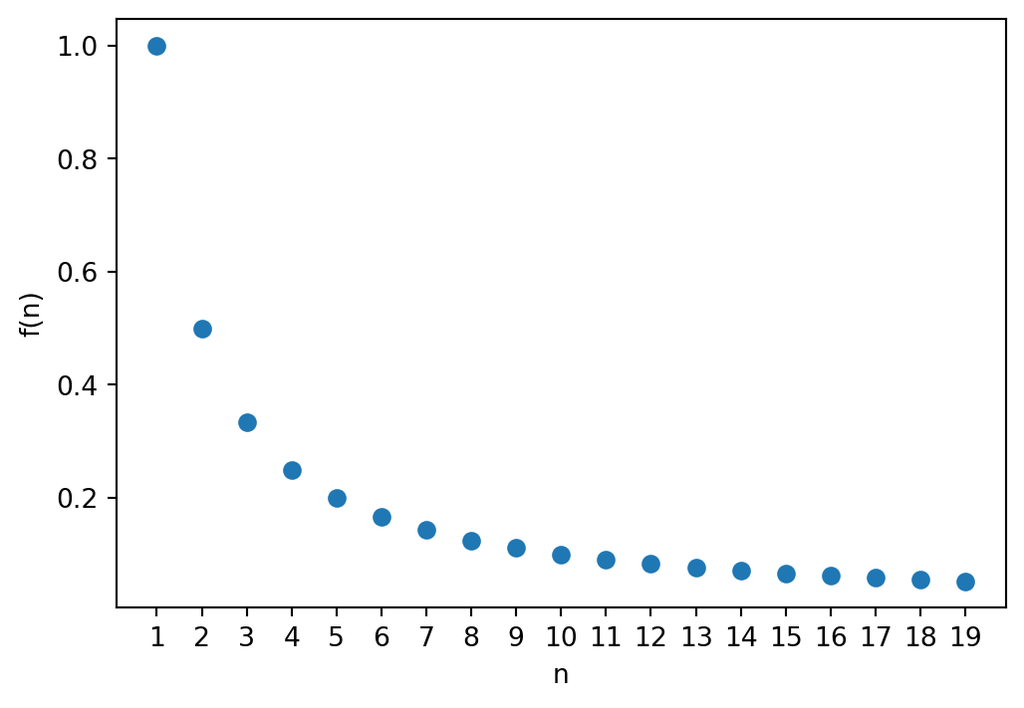

```python
import numpy as np
import matplotlib.pyplot as plt

def f(n):
    return 1/n

fig, ax = plt.subplots(figsize=(6,4))
n=np.arange(1,20)
plt.scatter(n,f(n))
plt.xlabel('n')
plt.ylabel('f(n)')
plt.xticks(np.arange(1,20,1))
plt.show()
```

where $\mathbb{N}$ denotes the set of natural numbers. This function assigns each $n$ the value $1/n$.

We often denote sequences using $f(n)=1/n$.

**Example 4**

The quadratic function often written as $f(x)=x^2$ is a function that assigns each $x$ the value $x^2$. In our notation, we write this as

$$f=\{(x,x^2): x \in \mathbb{R}\}$$

where $\mathbb{R}$ denotes the set of real numbers.

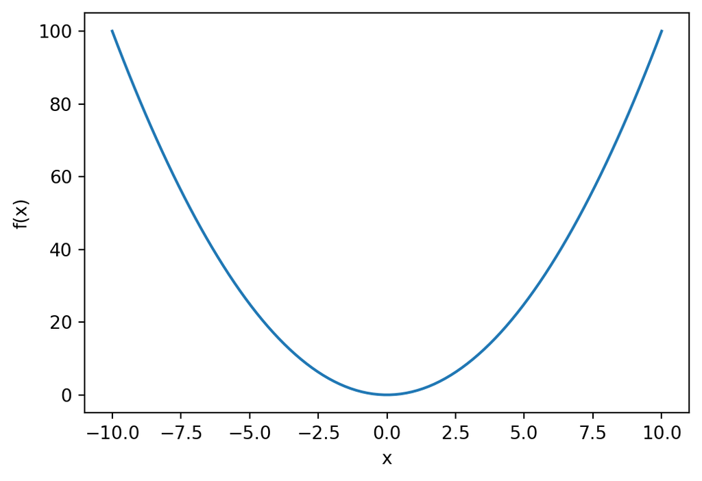

```python
def f(x):
    return x**2

fig, ax = plt.subplots(figsize=(6,4))
x=np.linspace(-10,10,100)
plt.plot(x,f(x))
plt.xlabel('x')
plt.ylabel('f(x)')
plt.show()
```

**Example 5**

The determinant of a matrix is a function that assigns each matrix a number. In our notation, we write this as

$$f=\{(M,\text{det}(M)): M \text{ is a square matrix}\}$$

**Example 6**

A matrix itself is also a function that assigns each pair of indices $(i,j)$ where $i,j \in \{1,2,...,n\}$ the element of the matrix at position $(i,j)$. In our notation, we write this as

$$M=\{((i,j),M_{ij}): i,j \in \{1,2,...,n\}\}$$

for convenience, we write this as a two-dimensional array:

$$M=\begin{bmatrix}
M_{11} & M_{12} & \cdots & M_{1n} \\
M_{21} & M_{22} & \cdots & M_{2n} \\
\vdots & \vdots & \ddots & \vdots \\
M_{n1} & M_{n2} & \cdots & M_{nn}
\end{bmatrix}$$

**Example 7**

Matrix addition is a function that assigns each pair of matrices their sum. In our notation, we write this as

$$f=\{((A,B),A+B): A,B \text{ are matrices of the same dimensions}\}$$

where $A+B$ is the matrix whose elements are the sums of the elements of matrices $A$ and $B$, that is, for each $i,j$ we have
$$(A+B)_{ij}=A_{ij}+B_{ij}$$

**Example 8**

A dictionary in Python is also a function that assigns each key a value. In our notation, we write this as:

```python
d={'a':1, 'b':2, 'c':3}
```

#### Geogebra examples

Check the following examples in [Geogebra](https://www.geogebra.org/?lang=en):

- ax^3 + bx^2 + cx + d
- sin(ax + b)
- e^( -x^2 / s)
- x^2 + y^3 = 1
- ImplicitCurve(xx+yyy-1) which is the same as the previous one
- ImplicitCurve(sin(x) + cos(y) - 1)

### Composition of functions

The composition of two functions $f$ and $g$ is written as $f\circ g$. It is a function that assigns each $x$ the value $(f\circ g)(x)=f(g(x))$. It is not hard to undestand mechanically what this means. We first apply $g$ to $x$ and then apply $f$ to the result:

$$x\mapsto g(x) \mapsto f(g(x))$$

##### Example 1

Let $f(x)=x^2$ and $g(x)=x+1$. Then the composition of these functions is

$$(f\circ g)(x)=f(g(x))=f(x+1)=(x+1)^2$$

##### Example 2

Let $f(x)=\sin(x)$ and $g(x)=x^2$. Then the composition $f\circ g$ is

$$(f\circ g)(x)=f(g(x))=f(x^2)=\sin(x^2)$$

but $g\circ f$ is

$$(g\circ f)(x)=g(f(x))=g(\sin(x))=\sin^2(x)$$

From these examples we see that the composition of functions is not commutative, that is, in general $f\circ g \neq g\circ f$.

Below is a Python code that visualizes the composition of two functions $f$ and $g$.

[figure not shown]

```python
import numpy as np
import matplotlib.pyplot as plt

def gf(x):
    return np.sin(x**2)

def fg(x):
    return np.sin(x)**2

fig, ax = plt.subplots(figsize=(6,4))
x=np.linspace(-6,6,1000)
plt.plot(x,gf(x),label='g(f(x))')
plt.plot(x,fg(x),label='f(g(x))')
plt.xlabel('x')
plt.ylabel('f(x)')
plt.legend()
plt.show()
```

## Limits of functions

### Sequences ($\mathbb{N}\rightarrow\mathbb{R}$)

Do not forget a sequence is a function that assigns each natural number a value, whcih we write as

$$\{(n,a_n): n \in \mathbb{N}\}=\{(0, a_0), (1, a_1), (2, a_2), ...\}$$

The argument is most often omitted, so we write this as

$$\{a_n\}=\{a_0, a_1, a_2, ...\}$$

An idea of a limit of sequence is very simple. It is a number that the sequence approaches as we take more and more elements of the sequence. For example, the sequence $a_n=\frac{1}{n}$ approaches 0 as we take more and more elements of the sequence. We write this as

$$\lim_{n \to \infty} a_n=0$$

Formal definition of a limit of a sequence is as follows:

#### Definition: Limit of a sequence

A number $g$ is the limit of a sequence $a_n$ if for every $\varepsilon>0$ there exists $N$ such that for every $n>N$ we have $|a_n-g|<\epsilon$. We write this as
$$\lim_{n \to \infty} a_n=g$$
.

[figure not shown]

```python
import numpy as np
import matplotlib.pyplot as plt

# Function definition
def a(n):
    return 3 * n**2 / (n**2 + 1)

# Parameters for visualization
epsilon = 0.1  # Epsilon value to represent the "margin" around the limit
N = 6  # Chosen N for the definition of limit

# Generate data points
n = np.arange(1, 20)  # Range of n values for plotting
a_values = a(n)  # Compute the function values

# Compute the limit for large n (L = 3)
limit = 3

# Create the plot
fig, ax = plt.subplots(figsize=(8, 5))
plt.scatter(n, a_values, label="Sequence $a(n) = \\frac{3n^2}{n^2 + 1}$", color="blue")  # Sequence points
plt.axhline(y=limit, color="green", linestyle="-", label="Limit $L = 3$")  # The limit line
plt.axhline(y=limit + epsilon, color="red", linestyle="--", label="$L + \\varepsilon$")  # Upper epsilon bound
plt.axhline(y=limit - epsilon, color="red", linestyle="--", label="$L - \\varepsilon$")  # Lower epsilon bound
plt.axvline(x=N, color="orange", linestyle="--", label="$N = 10$")  # Vertical line for N

# Annotate the plot
plt.title("Visualization of Limit of $a(n)$ as $n \\to \\infty$")
plt.xlabel("$n$")
plt.ylabel("$a(n)$")
plt.legend(loc="lower right")
plt.grid(True)

# Display the plot
plt.show()
```

Some important points to note about limits of sequences are:

1. The limit of a sequence is unique. This means that if a sequence has a limit, then this limit is unique.
2. If a sequence has a limit, then the sequence is bounded. This means that there exists a number $M$ such that $|a_n| \leq M$ for all $n$.

To compute the limit of a sequence, we often use the following rules:

1. The limit of a sum of sequences is the sum of the limits of the sequences.

$$\lim_{n \to \infty} (a_n\pm b_n)=\lim_{n \to \infty} a_n\pm\lim_{n \to \infty} b_n$$

2. The limit of a product of sequences is the product of the limits of the sequences.

$$\lim_{n \to \infty} (a_n \cdot b_n)=\lim_{n \to \infty} a_n \cdot \lim_{n \to \infty} b_n$$

3. The limit of a quotient of sequences is the quotient of the limits of the sequences.

$$\lim_{n \to \infty} \frac{a_n}{b_n}=\frac{\lim\limits_{n \to \infty} a_n}{\lim\limits_{n \to \infty} b_n}$$

4. The limit of a sequence raised to a power is the limit of the sequence raised to the power.

$$\lim_{n \to \infty} a_n^k=(\lim_{n \to \infty} a_n)^k$$

#### The Squeeze Theorem

If $a_n \leq b_n \leq c_n$ for all $n$ and $\lim\limits_{n \to \infty} a_n=\lim\limits_{n \to \infty} c_n=g$, then $\lim\limits_{n \to \infty} b_n=g$.

Interpretation of the Squeeze Theorem is that if a sequence is squeezed between two sequences that have the same limit, then the sequence itself has the same limit.

**Example**

Let:

$$a_n=-\frac{1}{n},
\quad
b_n=\frac{\sin(n)}{n}
, \quad
c_n=\frac{1}{n}$$

Then we have $a_n \leq b_n \leq c_n$ for all $n$. We also have

$$\lim_{n \to \infty} a_n=\lim_{n \to \infty} c_n=0$$

Therefore, by the Squeeze Theorem, we have

$$\lim_{n \to \infty} \frac{\sin(n)}{n}=0$$

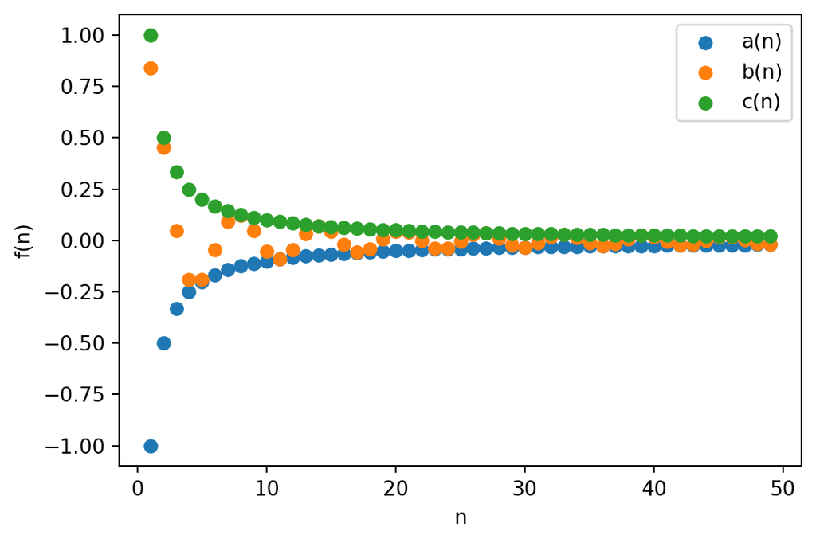

```python
import numpy as np
import matplotlib.pyplot as plt

def a(n):
    return -1/n
def b(n):
    return np.sin(n)/n
def c(n):
    return 1/n

fig, ax = plt.subplots(figsize=(6,4))
n=np.arange(1,50)
plt.scatter(n,a(n),label='a(n)')
plt.scatter(n,b(n),label='b(n)')
plt.scatter(n,c(n),label='c(n)')
plt.xlabel('n')
plt.ylabel('f(n)')
plt.legend()
plt.show()
```

### Limits of real functions ($\mathbb{R}\rightarrow\mathbb{R}$)

#### Definition

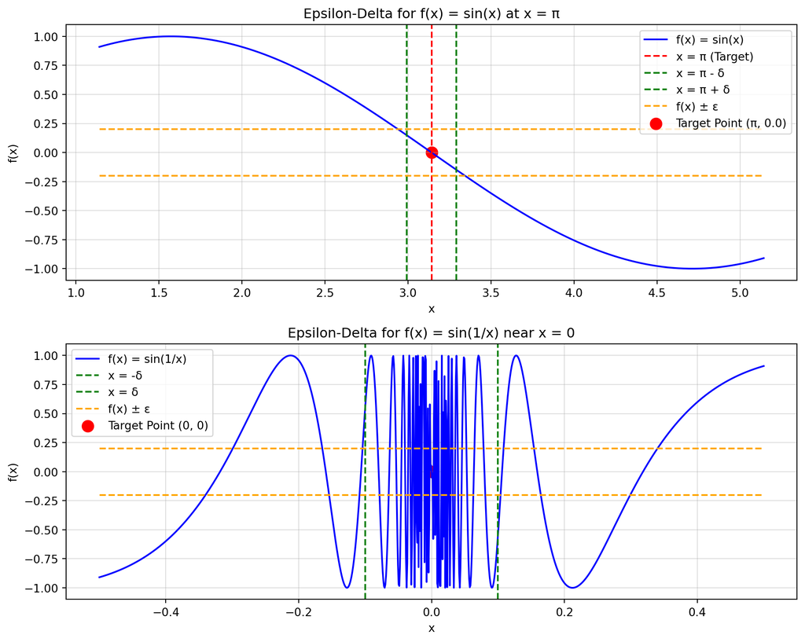

```python
# Import necessary libraries
import numpy as np
import matplotlib.pyplot as plt

# Function Definitions
def func_1(x):
    return np.sin(x)

def func_2(x):
    return np.sin(1 / x)

# Parameters for f(x) = sin(x) at x = π
epsilon_1 = 0.2  # Chosen epsilon
delta_1 = 0.15    # Chosen delta
target_x_1 = np.pi
target_y_1 = func_1(target_x_1)

# Parameters for f(x) = sin(1/x) near x = 0
epsilon_2 = 0.2  # Chosen epsilon
delta_2 = 0.1    # Chosen delta
target_x_2 = 0

# Generate x-values
x_values_1 = np.linspace(target_x_1 - 2, target_x_1 + 2, 500)
delta_range_1 = np.linspace(target_x_1 - delta_1, target_x_1 + delta_1, 500)

x_values_2 = np.linspace(-0.5, 0.5, 1000)
x_values_2 = x_values_2[x_values_2 != 0]  # Exclude zero for sin(1/x)
delta_range_2 = np.linspace(-delta_2, delta_2, 500)
delta_range_2 = delta_range_2[delta_range_2 != 0]  # Exclude zero

# Calculate function values
func_values_1 = func_1(x_values_1)
delta_func_values_1 = func_1(delta_range_1)

func_values_2 = func_2(x_values_2)
delta_func_values_2 = func_2(delta_range_2)

# Epsilon bands
y_upper_1 = target_y_1 + epsilon_1
y_lower_1 = target_y_1 - epsilon_1

y_upper_2 = epsilon_2
y_lower_2 = -epsilon_2

# Create side-by-side plots
fig, axs = plt.subplots(2,1, figsize=(10, 8))

# First plot: f(x) = sin(x), epsilon-delta
axs[0].plot(x_values_1, func_values_1, label="f(x) = sin(x)", color="blue")
axs[0].axvline(target_x_1, color="red", linestyle="--", label=f"x = π (Target)")
axs[0].axvline(target_x_1 - delta_1, color="green", linestyle="--", label=f"x = π - δ")
axs[0].axvline(target_x_1 + delta_1, color="green", linestyle="--", label=f"x = π + δ")
axs[0].hlines([y_upper_1, y_lower_1], target_x_1 - 2, target_x_1 + 2, colors="orange", linestyles="--", label="f(x) ± ε")
axs[0].scatter([target_x_1], [target_y_1], color="red", s=100, label=f"Target Point (π, {round(target_y_1, 2)})")
axs[0].set_title("Epsilon-Delta for f(x) = sin(x) at x = π")
axs[0].set_xlabel("x")
axs[0].set_ylabel("f(x)")
axs[0].grid(alpha=0.4)
axs[0].legend()

# Second plot: f(x) = sin(1/x), epsilon-delta near zero
axs[1].plot(x_values_2, func_values_2, label="f(x) = sin(1/x)", color="blue")
axs[1].axvline(-delta_2, color="green", linestyle="--", label=f"x = -δ")
axs[1].axvline(delta_2, color="green", linestyle="--", label=f"x = δ")
axs[1].hlines([y_upper_2, y_lower_2], -0.5, 0.5, colors="orange", linestyles="--", label="f(x) ± ε")
axs[1].scatter([0], [0], color="red", s=100, label=f"Target Point (0, 0)")
axs[1].set_title("Epsilon-Delta for f(x) = sin(1/x) near x = 0")
axs[1].set_xlabel("x")
axs[1].set_ylabel("f(x)")
axs[1].grid(alpha=0.4)
axs[1].legend()

# Adjust layout and show
plt.tight_layout()
plt.show()
```

The limit of a function describes the behavior of the function as its input approaches a certain value. We denote it as:

$$\lim_{x \to c} f(x) = L$$

This means that as $x$ approaches $c$, the values of $f(x)$ get arbitrarily close to $L$.

#### Formal Definition

**Definition**: Let $f(x)$ be a function defined on some open interval containing $c$, except possibly at $c$ itself. We say that

$$\lim_{x \to c} f(x) = L$$

if for every $\varepsilon > 0$ there exists a $\delta > 0$ such that whenever $0 < |x - c| < \delta$, we have

$$|f(x) - L| < \varepsilon.$$

Geogebra:

- [Aplet1](https://www.geogebra.org/m/cwvFraYf)
- [Aplet2](https://www.geogebra.org/m/ksuyccpy)

#### One-Sided Limits

Limits can also be evaluated as $x$ approaches $c$ from one side:

- **Left-hand limit**: If $x$ approaches $c$ from the left ($x \to c^-$), then:
  $$\lim_{x \to c^-} f(x) = L$$
- **Right-hand limit**: If $x$ approaches $c$ from the right ($x \to c^+$), then:
  $$\lim_{x \to c^+} f(x) = L$$

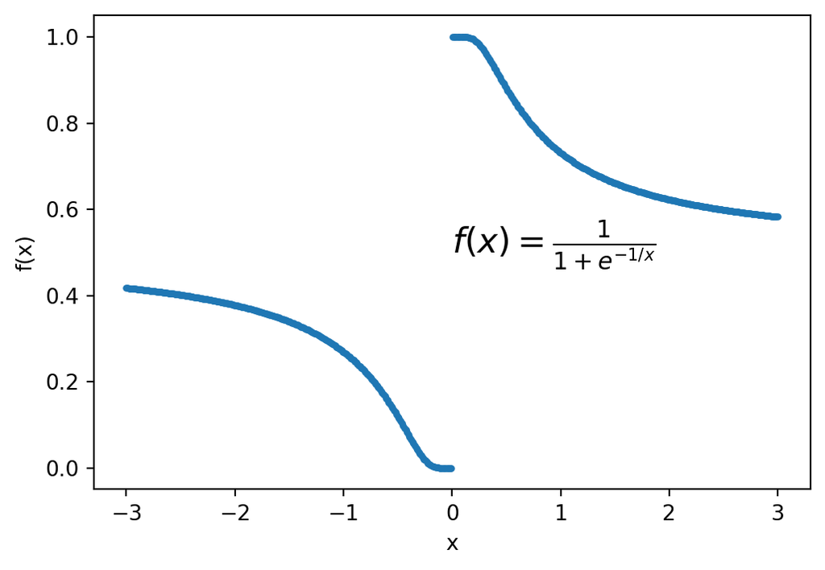

```python
import numpy as np
import matplotlib.pyplot as plt

def fun(x):
    return 1/(1+np.exp(-1/x))

fig, ax = plt.subplots(figsize=(6,4))
x=np.linspace(-3,3,500)
plt.scatter(x,fun(x),s=5)
plt.xlabel('x')
plt.ylabel('f(x)')
plt.text(0,0.5,r'$f(x)=\frac{1}{1+e^{-1/x}}$', fontsize=16)
plt.show()
```

The **two-sided limit** exists if and only if:
$$\lim_{x \to c^-} f(x) = \lim_{x \to c^+} f(x) = L.$$

#### Properties of Limits

For functions $f(x)$ and $g(x)$ with limits $\lim_{x \to c} f(x) = L_1$ and $\lim_{x \to c} g(x) = L_2$:

**Sum**:
$$\lim_{x \to c} [f(x) \pm g(x)] = \lim_{x \to c} f(x) \pm \lim_{x \to c} g(x) = L_1 + L_2$$

**Product**:
$$\lim_{x \to c} [f(x) \cdot g(x)] = \lim_{x \to c} f(x) \cdot \lim_{x \to c} g(x) = L_1 \cdot L_2$$

**Quotient** (if $\lim_{x \to c} g(x) \neq 0$):
$$\lim_{x \to c} \frac{f(x)}{g(x)} = \frac{\lim\limits_{x \to c} f(x)}{\lim\limits_{x \to c} g(x)} = \frac{L_1}{L_2}$$

**Power**:
$$\lim_{x \to c} [f(x)]^k = \left(\lim_{x \to c} f(x)\right)^k = L_1^k, \quad k \in \mathbb{R}.$$

### Limits at Infinity

If there is a number $L$ such that for every $\varepsilon > 0$ there exists a number $M$ such that for all $x > M$ we have $|f(x) - L| < \varepsilon$, then we write:
$$\lim_{x \to \infty} f(x) = L$$

Similarly, if there is a number $L$ such that for every $\varepsilon > 0$ there exists a number $M$ such that for all $x < M$ we have $|f(x) - L| < \varepsilon$, then we write:

$$\lim_{x \to -\infty} f(x) = L$$

#### Asymptotes

In mathematics, functions often exhibit interesting behavior as their inputs grow very large or very small. One such phenomenon is when a function approaches a straight line, called an **asymptote**, as $x$ becomes large.

If a function $f(x)$ approaches a line $y = ax + b$ as $x$ grows, we say the function has an **oblique asymptote** defined by the equation:

$$f(x) \sim ax + b \qquad \text{for large } x,$$

which formally means:

$$\lim_{x \to \infty} \big(f(x) - (ax + b)\big) = 0.$$

To find the slope $a$ of the asymptote:

$$a = \lim_{x \to \infty} \frac{f(x)}{x}.$$

To find the intercept $b$:

$$b = \lim_{x \to \infty} \big(f(x) - ax\big).$$

Example: Find the asymptotes of the function $f(x)=\frac{x^3+3x^2+1}{3x^2}$

First, we find the slope of the asymptote:

$$a=\lim_{x \to \infty} \frac{x^3+3x^2+1}{3x^2\cdot x}
=
\lim_{x \to \infty} \frac{1}{3}$$

Next, we find the intercept of the asymptote:

$$\begin{align*}
b
&=\lim_{x \to \infty} \left(\frac{x^3+3x^2+1}{3x^2}-\frac{1}{3}x\right)\\
&=\lim_{x \to \infty} \left(\frac{x^3+3x^2+1-x^3}{3x^2}\right)\\
&=\lim_{x \to \infty} \left(\frac{3x^2+1}{3x^2}\right)\\
&=\lim_{x \to \infty} \left(1+\frac{1}{3x^2}\right)\\
&=1
\end{align*}$$

Therefore, the asymptote of the function $f(x)=\frac{x^3+3x^2+1}{3x^2}$ is $y=\frac{1}{3}x+1$.

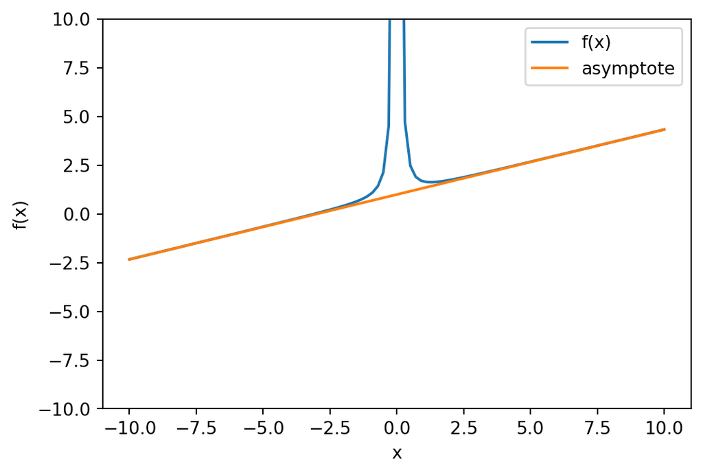

```python
import numpy as np
import matplotlib.pyplot as plt
def f(x):
    return (x**3+3*x**2+1)/(3*x**2)

def line(x):
    return 1/3*x+1

fig, ax = plt.subplots(figsize=(6,4))
x=np.linspace(-10,10,100)
plt.plot(x,f(x),label='f(x)')
plt.plot(x,line(x),label='asymptote')
plt.xlabel('x')
plt.ylabel('f(x)')
plt.legend()
plt.ylim(-10,10)
plt.show()
```

## Countinuity

### Definition

A function $f(x)$ is **continuous** at a point $x = a$ if the following three conditions are satisfied:

1. $f(a)$ is defined.  
   This means that the function must have a value at $x = a$. If $f(a)$ is not defined, the function cannot be continuous at that point.
2. $\lim\limits_{x \to a} f(x)$ exists.  
   The limit of $f(x)$ as $x$ approaches $a$ must exist. This ensures that the function does not have a “jump” or oscillation around $x = a$.
3. $\lim\limits_{x \to a} f(x) = f(a)$.  
   The value of the limit as $x$ approaches $a$ must equal the actual value of the function at $x = a$. This condition guarantees that there is no “hole” or discontinuity at the point.

If any of these conditions fail, the function is not continuous at $x = a$.

### Intuition

Continuity intuitively means that the graph of a function can be drawn without lifting the pen from the paper. For instance:

- Polynomials like $f(x) = x^2 + 3x + 2$ are continuous everywhere.
- Piecewise functions may fail to be continuous if there is a jump, hole, or break in their definition.

### Types of Discontinuities

When a function is not continuous at $x = a$, we classify the discontinuity into three types:

1. **Removable Discontinuity**:  
   Occurs when $\lim_{x \to a} f(x)$ exists, but $f(a)$ is not defined or differs from the limit.  
   Example: $f(x) = \frac{x^2 - 1}{x - 1}$ has a removable discontinuity at $x = 1$.
2. **Jump Discontinuity**:  
   Occurs when the left-hand limit $\lim_{x \to a^-} f(x)$ and right-hand limit $\lim_{x \to a^+} f(x)$ exist but are not equal.  
   Example: A piecewise function with different definitions on either side of $x = a$.
3. **Infinite Discontinuity**:  
   Occurs when $f(x)$ approaches infinity or negative infinity as $x$ approaches $a$.  
   Example: $f(x) = \frac{1}{x}$ has an infinite discontinuity at $x = 0$.

## Derivatives

### Definition

The **derivative** of a function $f(x)$ at a point $x=a$ is defined as:

$$f'({\color{red}a}) = \lim_{{\color{blue}h} \to 0} \frac{f({\color{red}a}+{\color{blue}h}) - f({\color{red}a})}{{\color{blue}h}}$$
This limit represents the slope of the tangent line to the curve $y=f(x)$ at the point $(a, f(a))$.

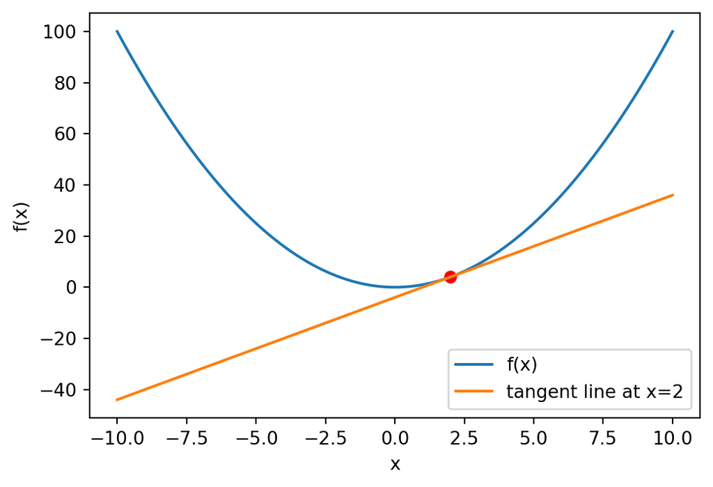

```python
import numpy as np
import matplotlib.pyplot as plt

def f(x):
    return x**2

def f_prime(x):
    return 2*x

def tangent_line(x, a):
    return f_prime(a)*(x-a) + f(a)

fig, ax = plt.subplots(figsize=(6,4))
x=np.linspace(-10,10,100)
plt.plot(x,f(x),label='f(x)')
plt.plot(x,tangent_line(x,2),label='tangent line at x=2')
plt.xlabel('x')
plt.ylabel('f(x)')
plt.legend()
plt.scatter(2,f(2),color='red')
plt.show()
```

### Interpretation

1. **Slope of the Tangent Line**:  
   The derivative is the slope of the line that just “touches” the curve at a single point without crossing it (locally). This tangent line provides a linear approximation to the function near that point.
2. **Instantaneous Rate of Change**:  
   If $f(x)$ represents position, then $f'(x)$ represents velocity—how quickly the position is changing at a specific moment.
3. **Geometric Insight**:  
   At points where the derivative is:
   - **Positive** ($f'(x) > 0$): The function is increasing.
   - **Negative** ($f'(x) < 0$): The function is decreasing.
   - **Zero** ($f'(x) = 0$): The function has a horizontal tangent line, potentially a local maximum, minimum, or inflection point.
4. **Practical Example**:  
   Consider the function $f(x) = x^2$. The derivative $f'(x) = 2x$ tells us that the slope of the curve increases as $x$ increases, meaning the curve becomes steeper as you move away from the origin.

**Example**: Let $f(x)=\sin(x)$. Then the derivative of $f(x)$ at $x=a$ is $f'(a)=\cos(a)$. Now we will prove this.

**Proof**: From trigonometry, we know that $sin(a+h)=sin(a)cos(h)+cos(a)sin(h)$. Therefore, we have

$$\begin{align*}
f'({\color{red}a})
&=\lim_{{\color{blue}h} \to 0} \frac{\sin({\color{red}a}+{\color{blue}h})-\sin({\color{red}a})}{{\color{blue}h}}\\
&=\lim_{{\color{blue}h} \to 0} \frac{\sin({\color{red}a})\cos({\color{blue}h})+\cos({\color{red}a})\sin({\color{blue}h})-\sin({\color{red}a})}{{\color{blue}h}}\\
&=\lim_{{\color{blue}h} \to 0} \frac{\sin({\color{red}a})(\cos({\color{blue}h})-1)+\cos({\color{red}a})\sin({\color{blue}h})}{{\color{blue}h}}\\
&=\cos({\color{red}a})\lim_{{\color{blue}h} \to 0} \frac{\sin({\color{blue}h})}{{\color{blue}h}}\\
&=\cos({\color{red}a})
\end{align*}$$

**Example**: Let $f(x)=x^3$. Then the derivative of $f(x)$ at $x=a$ is $f'(a)=3a^2$. Now we will prove this.

**Proof**: We have

$$\begin{align*}
f'({\color{red}a})&=
\lim_{{\color{blue}h} \to 0} \frac{({\color{red}a}+{\color{blue}h})^3-{\color{red}a}^3}{{\color{blue}h}}\\
&=\lim_{{\color{blue}h} \to 0} \frac{{\color{red}a}^3+3{\color{red}a}^2{\color{blue}h}+3{\color{red}a}{\color{blue}h}^2+{\color{blue}h}^3-{\color{red}a}^3}{{\color{blue}h}}\\
&=\lim_{{\color{blue}h} \to 0} 3{\color{red}a}^2+3{\color{red}a}{\color{blue}h}+{\color{blue}h}^2\\
&=3{\color{red}a}^2
\end{align*}$$

#### Basic Derivatives

| Function $f(x)$ | Derivative $f'(x)$ |
| --- | --- |
| $c$ | $0$ |
| $x$ | $1$ |
| $x^n$ | $nx^{n-1}$ |
| $e^x$ | $e^x$ |
| $a^x$ | $a^x \ln(a)$ |
| $\ln(x)$ | $\frac{1}{x}$ |
| $\log_a(x)$ | $\frac{1}{x \ln(a)}$ |
| $\sin(x)$ | $\cos(x)$ |
| $\cos(x)$ | $-\sin(x)$ |

### Basic Theorems

**Basics**

$$\begin{align*}
({\color{red}f}\pm {\color{blue}g})'(x)&={\color{red}f}'(x)\pm {\color{blue}g}'(x)\\
({\color{red}f}{\color{blue}g})'(x)&={\color{red}f}'(x){\color{blue}g}(x)+{\color{red}f}(x){\color{blue}g}'(x)\\
\left(\frac{{\color{red}f}}{{\color{blue}g}}\right)'(x)&=\frac{{\color{red}f}'(x){\color{blue}g}(x)-{\color{red}f}(x){\color{blue}g}'(x)}{{\color{blue}g}^2(x)}\\
({\color{red}f}^n)'(x)&=n{\color{red}f}'(x){\color{red}f}^{n-1}(x)
\end{align*}$$

**Applications**

$$\begin{align*}
({\color{blue}{\cos(x)}}{\color{red}{e^x}})'
&= ({\color{blue}{\cos(x)}})' {\color{red}{e^x}} + {\color{blue}{\cos(x)}} ({\color{red}{e^x}})' \\[5pt]
&= {\color{blue}{-\sin(x)}} {\color{red}{e^x}} + {\color{blue}{\cos(x)}} {\color{red}{e^x}} \\[5pt]
&= ({\color{blue}{\cos(x)}} - {\color{blue}{\sin(x)}}) {\color{red}{e^x}}
\end{align*}$$

##### Third example

$$\begin{align*}
\tan(x)
&= \left(\frac{\color{blue}{\sin(x)}}{\color{red}{\cos(x)}}\right)' \\[5pt]
&= \frac{(\color{blue}{\sin(x)})'(\color{red}{\cos(x)}) - (\color{red}{\cos(x)})'(\color{blue}{\sin(x)})}{(\color{red}{\cos(x)})^2} \\[5pt]
&= \frac{\color{blue}{\cos(x)}\color{red}{\cos(x)} - (\color{red}{-\sin(x)})(\color{blue}{\sin(x)})}{(\color{red}{\cos(x)})^2} \\[5pt]
&= \frac{\color{red}{\cos^2(x)} + \color{blue}{\sin^2(x)}}{\color{red}{\cos^2(x)}} \\[5pt]
&= \frac{1}{\color{red}{\cos^2(x)}}
\end{align*}$$

#### Chain Rule

This is a very important rule that allows us to differentiate composite functions. If ${\color{red}f}(x)={\color{blue}g}({\color{green}h}(x))$, then
$${\color{red}f}'(x)={\color{blue}g}'({\color{green}h}(x)){\color{green}h}'(x)$$

##### First example

Let ${\color{red}f}(x)={\color{blue}\sin}({\color{green}x^2})$. Then

- ${\color{blue}g}(y)=\sin(y) \Rightarrow {\color{blue}g}'(y)=\cos(y)$
- ${\color{green}h}(x)=x^2 \Rightarrow {\color{green}h}'(x)=2x$

so

$$\begin{align*}
{\color{red}f}'(x)&={\color{blue}g}'({\color{green}h}(x)){\color{green}h}'(x)=\cos(x^2)\cdot 2x
\end{align*}$$

##### Second example

Let $f(x)=e^{x^2+\cos(x)}$. Then

- $g(y)=e^y \Rightarrow g'(y)=e^y$
- $h(x)=x^2+\cos(x) \Rightarrow h'(x)=2x-\sin(x)$

so

$$\begin{align*}
f'(x)&=g'(h(x))h'(x)=e^{x^2+\cos(x)}\cdot (2x-\sin(x))
\end{align*}$$

### Finding Extrema

Extrema of a function are points where the function reaches its **maximum** or **minimum** values, either locally (in a neighborhood) or globally (on the entire domain). To find extrema, we use the following process:

#### Steps to Find Extrema

1. **Compute the Derivative**:  
   Find the first derivative $f'(x)$ of the function $f(x)$. The derivative represents the slope of the tangent line.
2. **Set the Derivative to Zero**:  
   Solve the equation $f'(x) = 0$. These points are called **critical points**, where the function’s slope is horizontal.
3. **Check for Undefined Points**:  
   Identify points where $f'(x)$ does not exist but $f(x)$ is still defined. These can also be critical points.
4. **Use the Second Derivative Test** (Optional):  
   Compute the second derivative $f''(x)$ to determine the nature of each critical point:
   - If $f''(x) > 0$, the function has a local minimum at that point.
   - If $f''(x) < 0$, the function has a local maximum at that point.
   - If $f''(x) = 0$, the test is inconclusive. Use other methods, such as analyzing the function’s behavior.
5. **Boundary Points** (if the domain is restricted):  
   For a function defined on a closed interval $[a, b]$, evaluate $f(a)$ and $f(b)$, as extrema can occur at the boundaries.

#### Necessary Conditions for Extrema

- A point $x=c$ is a **candidate** for an extremum if:
  1. $f'(c) = 0$ (critical point), or
  2. $f'(c)$ is undefined but $f(c)$ is defined.
- A point is a **local extremum** only if it satisfies the conditions above and meets additional criteria (e.g., second derivative test or sign change in $f'(x)$).

#### Example

Consider the function $f(x) = x^3 - 3x^2 + 4$:

1. Compute the first derivative:  
   $f'(x) = 3x^2 - 6x$.
2. Solve $f'(x) = 0$:  
   $3x^2 - 6x = 0$  
   $x(x-2) = 0$  
   Critical points are $x = 0$ and $x = 2$.
3. Compute the second derivative:  
   $f''(x) = 6x - 6$.
   - At $x = 0$: $f''(0) = -6$ (local maximum).
   - At $x = 2$: $f''(2) = 6$ (local minimum).
4. Evaluate boundaries (if applicable):  
   Not relevant here, as the domain is not restricted.

#### Conclusion

Extrema occur at $x = 0$ (local maximum) and $x = 2$ (local minimum). Use this structured approach to identify extrema systematically.

### Applications in Computer Science

Finding extrema plays a critical role in computer science, particularly in solving **optimization problems**. Optimization involves determining the maximum or minimum value of a function, often under specific constraints. Here are some key applications:

#### 1. **Machine Learning**

In machine learning, training models often involves minimizing a loss function, which measures the error between the predicted and actual values. For example:

- Gradient Descent: An optimization algorithm that uses derivatives to find the minimum of a function (e.g., loss function).
- Convergence to a Global Minimum: Finding extrema ensures the model learns the best possible parameters.

#### 2. **Data Analysis and Fitting**

In data analysis, functions are fit to data points (e.g., regression models) by minimizing error metrics. The derivative helps identify the optimal parameters for the function.

#### 3. **Algorithm Design**

Many algorithms in computer science involve optimization:

- Pathfinding Algorithms: Algorithms like Dijkstra’s and A* aim to minimize the cost of reaching a destination.
- Scheduling Problems: Finding the minimum time or resources required to complete tasks.

#### 4. **Computer Graphics**

Optimization is critical in computer graphics for rendering, animation, and physics simulations. Examples include:

- Minimizing energy functions for realistic cloth or fluid simulations.
- Optimizing curves and surfaces for smooth rendering.

#### 5. **Operations Research**

In operations research, optimization is used to solve problems involving resource allocation, scheduling, and logistics. For example:

- Linear Programming: Derivatives are used in the simplex method to maximize or minimize objective functions.
- Nonlinear Optimization: Extrema are crucial in finding optimal solutions to more complex problems.

#### 6. **Artificial Intelligence**

In AI, optimization problems arise in areas like:

- Game Theory: Finding optimal strategies for agents by maximizing rewards or minimizing losses.
- Reinforcement Learning: Optimizing policies to maximize cumulative rewards over time.

#### Example: Gradient Descent in Neural Networks

In neural networks, the goal is to minimize the loss function during training. The process involves:

1. Computing the gradient (derivative) of the loss function with respect to the model parameters.
2. Updating the parameters in the direction opposite to the gradient to reduce the loss.

Mathematically:
$$\theta_{t+1} = \theta_t - \eta \nabla L(\theta_t)$$
where:

- $\theta_t$: Current parameters
- $\eta$: Learning rate
- $\nabla L(\theta_t)$: Gradient of the loss function

This iterative process uses derivatives to converge toward a minimum, improving model performance.

#### Conclusion

The ability to find extrema is fundamental to numerous optimization problems in computer science, enabling efficient algorithms and solutions across various domains, from machine learning to operations research.

## Taylor Series

### Definition

The **Taylor series** of a function $f(x)$ at a point $x=a$ is an infinite sum of terms that are calculated from the derivatives of $f(x)$ at $x=a$. It is given by:

$$f(x) = f(a) + f'(a)(x-a) + \frac{f''(a)}{2!}(x-a)^2 +
\cdots+
\frac{f^{n-1}(a)}{(n-1)!}(x-a)^{n-1}+R_n(x)$$

where $R_n(x)$ is the remainder term, which is given by:

$$R_n(x) = \frac{f^{(n)}(c)}{n!}(x-a)^n \quad \text{for some } c\in(a,x)$$

How to read this

**First approximation**

$$\begin{align*}
f(x) &= f(a) + f'(a)(x-a)+R_1(x)\\
&=f(a)+f'(a)(x-a)+\frac{f''(c)}{2!}(x-a)^2
\end{align*}$$

**Second approximation**

$$\begin{align*}
f(x) &= f(a) + f'(a)(x-a)+\frac{f''(a)}{2!}(x-a)^2+R_2(x)\\
&=f(a)+f'(a)(x-a)+\frac{f''(a)}{2!}(x-a)^2+\frac{f'''(c)}{3!}(x-a)^3
\end{align*}$$

etc.

**Example**: Let $f(x)=sin(x)$. Then the Taylor series of $f(x)$ at $x=0$ is

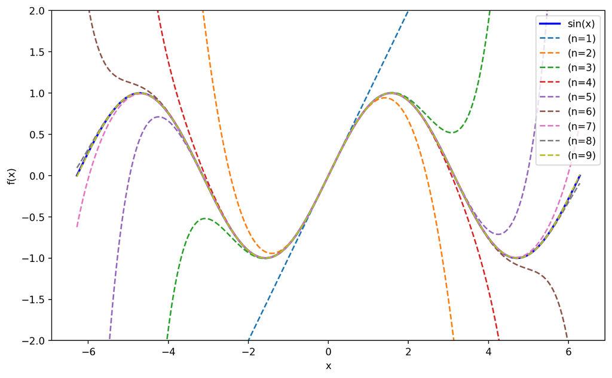

```python
import numpy as np
from scipy.special import factorial
import matplotlib.pyplot as plt

def f(x):
    return np.sin(x)

def taylor_series(x, n):
    result = 0
    for i in range(n):
        result += (-1)**i * x**(2*i+1) / factorial(2*i+1)
    return result

fig, ax = plt.subplots(figsize=(10,6))
x = np.linspace(-2*np.pi, 2*np.pi, 1000)

plt.plot(x, f(x), label='sin(x)', color='blue', linestyle='-', linewidth=2)
for i in range(1, 10):
    plt.plot(x, taylor_series(x, i), label=f'(n={i})', linestyle='--')

plt.ylim(-2, 2)

plt.xlabel('x')
plt.ylabel('f(x)')
plt.legend()
plt.show()
```

#### Examples

$$\begin{align*}
e^x&=1+x+\frac{x^2}{2!}+\frac{x^3}{3!}+\cdots = \sum_{n=0}^{\infty} \frac{x^n}{n!}\\
\sin(x)&=x-\frac{x^3}{3!}+\frac{x^5}{5!}-\cdots=
\sum_{n=0}^{\infty} (-1)^n \frac{x^{2n+1}}{(2n+1)!}\\
\cos(x)&=1-\frac{x^2}{2!}+\frac{x^4}{4!}-\cdots=
\sum_{n=0}^{\infty} (-1)^n \frac{x^{2n}}{(2n)!}\\
\ln(1+x)&=x-\frac{x^2}{2}+\frac{x^3}{3}-\cdots=
\sum_{n=1}^{\infty} (-1)^{n-1} \frac{x^n}{n}\\
\frac{1}{1+x}&=1-x+x^2-x^3+\cdots=
\sum_{n=0}^{\infty} (-1)^n x^n
\end{align*}$$

## Integrals

### Rieman Integral

The **Riemann integral** of a function $f(x)$ over the interval $[a,b]$ is defined as:

$$\int_{a}^{b} f(x) \, dx = \lim_{n \to \infty} \sum_{i=1}^{n} f(x_i) \Delta x$$

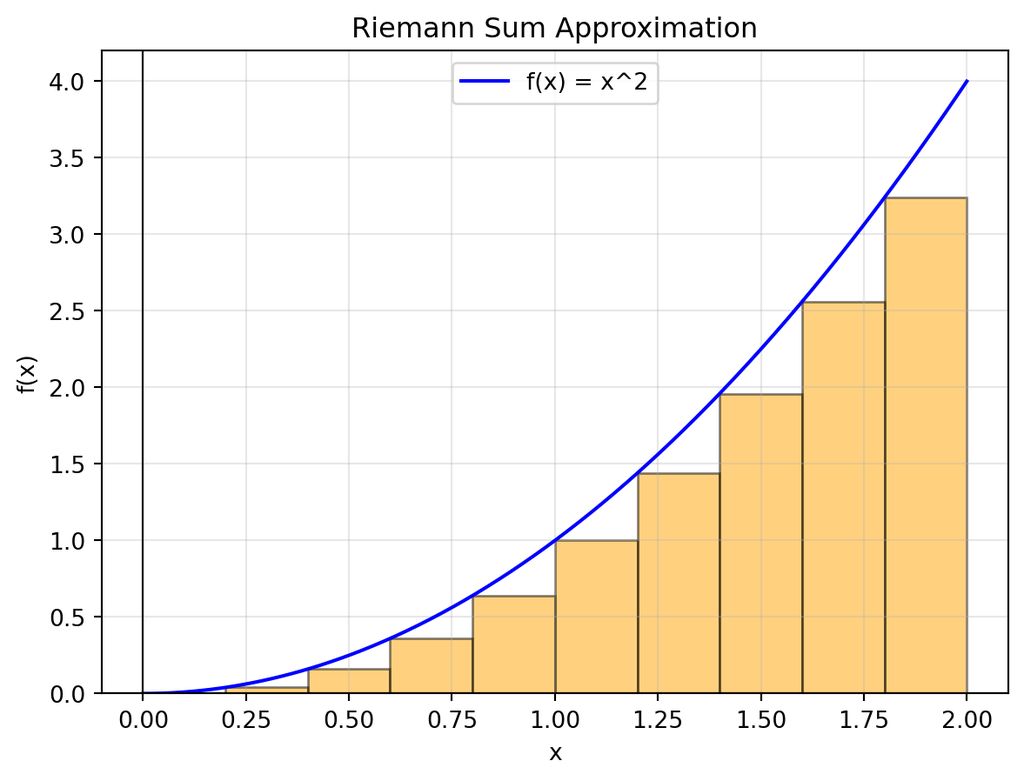

```python
import numpy as np
import matplotlib.pyplot as plt

# Define the function to integrate
def f(x):
    return x**2

# Define the interval [a, b]
a, b = 0, 2

# Number of rectangles
n = 10

# Calculate the width of each rectangle
dx = (b - a) / n

# Define the x values for the left endpoints
x = np.linspace(a, b, n, endpoint=False)

# Calculate the y values (height of rectangles)
y = f(x)

# Plot the function
x_fine = np.linspace(a, b, 500)
plt.plot(x_fine, f(x_fine), label='f(x) = x^2', color='blue')

# Draw the rectangles
for i in range(n):
    plt.bar(x[i], y[i], width=dx, align='edge', edgecolor='black', color='orange', alpha=0.5)

# Add labels and title
plt.title('Riemann Sum Approximation')
plt.xlabel('x')
plt.ylabel('f(x)')
plt.axhline(0, color='black', linewidth=0.8)
plt.axvline(0, color='black', linewidth=0.8)
plt.legend()
plt.grid(alpha=0.3)

# Show the plot
plt.show()
```

[interactive chart not shown]

### Properties of Integrals

**Linearity**

$$\int_{a}^{b} [f(x) \pm g(x)] \, dx = \int_{a}^{b} f(x) \, dx \pm \int_{a}^{b} g(x) \, dx$$

$$\int_{a}^{b} c f(x) \, dx = c \int_{a}^{b} f(x) \, dx$$

**Change of Variables**

If $x=g(t)$ is a differentiable function on $[a,b]$ and $f$ is continuous on the range of $g$, then

$$\int_{a}^{b} f(g(t))g'(t) \, dt = \int_{g(a)}^{g(b)} f(x) \, dx$$

**Integration by Parts**

$$\int u \, dv = uv - \int v \, du$$

### Fundamental Theorem of Calculus

Let $f(x)$ be a continuous function on $[a,b]$. Then the function $F(x)$ defined by

$$F(x)=\int_{a}^{x} f(t) \, dt$$

is continuous on $[a,b]$, differentiable on $(a,b)$, and

$$F'(x)=f(x)$$

##### Proof

Let $x_0 \in (a,b)$. Then

$$\begin{align*}
F'(x_0)&=\lim_{h \to 0} \frac{F(x_0+h)-F(x_0)}{h}\\
&=\lim_{h \to 0} \frac{\int_{a}^{x_0+h} f(t) \, dt-\int_{a}^{x_0} f(t) \, dt}{h}\\
&=\lim_{h \to 0} \frac{\int_{x_0}^{x_0+h} f(t) \, dt}{h}\\
&=\lim_{h \to 0} \frac{f(x_0+\theta h)h}{h}\\
&=f(x_0)
\end{align*}$$